# Jason Ficorilli DS 220 Project 2 - Exploring Pennsylvania's 2022 Motor Vehicle Crash Data

### Introduction:

Driving is an essential aspect of daily life for many residents in the state of Pennsylvania. According to the Pennsylvania Department of Transportation (PennDOT), 85.6% of Pennsylvania county residents over the age of 16 on average hold a drivers license [1]. However, while motor vehicles provide many benefits opposed to other means of transportation, vehicular crashes are a serious concern for statewide transportation logistics and public safety. Therefore, information and insights gathered from motor vehicle crash data can be beneficial to many relevant personal, business, and government stakeholders looking to improve the quality of transportation safety in the state.

In this project, I utilized various data analysis packages in Python to analyze crash data from the state of Pennsylvania. I used data from the online PennDOT Crash Information Tool to evaluate relevant trends in motor vehicle crashes during the year 2022 [2]. The 2022 statewide dataset is the most recent publically-avaiable crash dataset for Pennsylvania and contains 100 columns of information related to the location, type of vechile(s) involved, and injury/fatality counts (among many other column types) for reportable crash incidents. According to PennDOT, a "reportable crash" is a crash where a vehicle received damage to the degree that it can not be driven away under its own power and therefore must be towed, or any injury or death occurs to any person involved [3]. The dataset therefore does not contain information about small or non-reportable accidents (i.e. "fender benders").

This project consisted of two parts:

1. Reading in and cleaning the crash dataset
2. Analyzing relevant questions about the dataset using tools from the Pandas and Matplotlib data anlaysis packages in Python.

The questions I evaluated are as follows:

1. What were the top 10 PA counties with the most reportable crashes in 2022?
2. What were the top 10 PA counties with the most reportable crashes per capita in 2022?
3. Which months had the most crashes?
4. Which day of the week had the most crashes?
5. What were the top 10 hours of the day that had the most crashes?
6. Of crashes for drivers aged 16-20, 21-49, 50-64, 65-74, and 75+, which age group had the most drivers involved?
7. Of crashes for drivers aged 16, 17, 18, and 20 which age group had the most drivers involved?

## Part 1 - Reading in and Cleaning the Crash Dataset

After downloading the crash dataset from PennDot's website, I first imported the Pandas and Matplotlib packages. I then read the dataset into a Pandas dataframe, "crash_data."

```python
# Importing necessary packages
import pandas as pd
import matplotlib.pyplot as plt
crash_data = pd.read_csv('CRASH_STATEWIDE_2022.csv')
```

To gain an initial understanding of the dataset's structure, I used the "head()" and "tail()" functions to visualize the frist and last five elements in the dataset, as well as the "shape" function to see the dataset's number of rows and columns.

```python
crash_data.head(5)
```

|  | CRN | ARRIVAL_TM | AUTOMOBILE_COUNT | BELTED_DEATH_COUNT | BELTED_SUSP_SERIOUS_INJ_COUNT | BICYCLE_COUNT | BICYCLE_DEATH_COUNT | BICYCLE_SUSP_SERIOUS_INJ_COUNT | BUS_COUNT | CHLDPAS_DEATH_COUNT | ... | WORK_ZONE_TYPE | WORKERS_PRES | WZ_CLOSE_DETOUR | WZ_FLAGGER | WZ_LAW_OFFCR_IND | WZ_LN_CLOSURE | WZ_MOVING | WZ_OTHER | WZ_SHLDER_MDN | WZ_WORKERS_INJ_KILLED |
| --- | --- | --- | --- | --- | --- | --- | --- | --- | --- | --- | --- | --- | --- | --- | --- | --- | --- | --- | --- | --- | --- |
| 0 | 2022048971 | 6.0 | 2 | 0 | 0 | 0 | 0 | 0 | 0 | 0 | ... | NaN | NaN | NaN | NaN | NaN | NaN | NaN | NaN | NaN | NaN |
| 1 | 2022050472 | 1028.0 | 2 | 0 | 0 | 0 | 0 | 0 | 0 | 0 | ... | NaN | NaN | NaN | NaN | NaN | NaN | NaN | NaN | NaN | NaN |
| 2 | 2022052006 | 1345.0 | 0 | 0 | 0 | 0 | 0 | 0 | 0 | 0 | ... | NaN | NaN | NaN | NaN | NaN | NaN | NaN | NaN | NaN | NaN |
| 3 | 2022052044 | 1335.0 | 0 | 0 | 0 | 0 | 0 | 0 | 0 | 0 | ... | NaN | NaN | NaN | NaN | NaN | NaN | NaN | NaN | NaN | NaN |
| 4 | 2022047585 | 844.0 | 0 | 0 | 0 | 0 | 0 | 0 | 0 | 0 | ... | NaN | NaN | NaN | NaN | NaN | NaN | NaN | NaN | NaN | NaN |

5 rows × 100 columns

```python
crash_data.tail(5)
```

|  | CRN | ARRIVAL_TM | AUTOMOBILE_COUNT | BELTED_DEATH_COUNT | BELTED_SUSP_SERIOUS_INJ_COUNT | BICYCLE_COUNT | BICYCLE_DEATH_COUNT | BICYCLE_SUSP_SERIOUS_INJ_COUNT | BUS_COUNT | CHLDPAS_DEATH_COUNT | ... | WORK_ZONE_TYPE | WORKERS_PRES | WZ_CLOSE_DETOUR | WZ_FLAGGER | WZ_LAW_OFFCR_IND | WZ_LN_CLOSURE | WZ_MOVING | WZ_OTHER | WZ_SHLDER_MDN | WZ_WORKERS_INJ_KILLED |
| --- | --- | --- | --- | --- | --- | --- | --- | --- | --- | --- | --- | --- | --- | --- | --- | --- | --- | --- | --- | --- | --- |
| 116032 | 2023003037 | 1857.0 | 0 | 0 | 0 | 0 | 0 | 0 | 0 | 0 | ... | NaN | NaN | NaN | NaN | NaN | NaN | NaN | NaN | NaN | NaN |
| 116033 | 2023008262 | 1857.0 | 0 | 0 | 0 | 0 | 0 | 0 | 0 | 0 | ... | NaN | NaN | NaN | NaN | NaN | NaN | NaN | NaN | NaN | NaN |
| 116034 | 2023008404 | 1446.0 | 1 | 0 | 0 | 0 | 0 | 0 | 0 | 0 | ... | NaN | NaN | NaN | NaN | NaN | NaN | NaN | NaN | NaN | NaN |
| 116035 | 2023003848 | 805.0 | 3 | 0 | 0 | 0 | 0 | 0 | 0 | 0 | ... | NaN | NaN | NaN | NaN | NaN | NaN | NaN | NaN | NaN | NaN |
| 116036 | 2023007611 | 1558.0 | 0 | 0 | 0 | 0 | 0 | 0 | 0 | 0 | ... | NaN | NaN | NaN | NaN | NaN | NaN | NaN | NaN | NaN | NaN |

5 rows × 100 columns

```python
crash_data.shape
```

```
(116037, 100)
```

As previously mentioned, the dataset has 100 columns with information related to Pennsylvania motor vehicle crashes, as well as over 116,000 crash entries. To better understand the dataset's organizaiton, I visualized a list of the dataset's column names:

```python
crash_data.columns
```

```
Index(['CRN', 'ARRIVAL_TM', 'AUTOMOBILE_COUNT', 'BELTED_DEATH_COUNT',
       'BELTED_SUSP_SERIOUS_INJ_COUNT', 'BICYCLE_COUNT', 'BICYCLE_DEATH_COUNT',
       'BICYCLE_SUSP_SERIOUS_INJ_COUNT', 'BUS_COUNT', 'CHLDPAS_DEATH_COUNT',
       'CHLDPAS_SUSP_SERIOUS_INJ_COUNT', 'COLLISION_TYPE', 'COMM_VEH_COUNT',
       'CONS_ZONE_SPD_LIM', 'COUNTY', 'CRASH_MONTH', 'CRASH_YEAR',
       'DAY_OF_WEEK', 'DEC_LAT', 'DEC_LONG', 'DISPATCH_TM', 'DISTRICT',
       'DRIVER_COUNT_16YR', 'DRIVER_COUNT_17YR', 'DRIVER_COUNT_18YR',
       'DRIVER_COUNT_19YR', 'DRIVER_COUNT_20YR', 'DRIVER_COUNT_50_64YR',
       'DRIVER_COUNT_65_74YR', 'DRIVER_COUNT_75PLUS', 'EST_HRS_CLOSED',
       'FATAL_COUNT', 'HEAVY_TRUCK_COUNT', 'HORSE_BUGGY_COUNT', 'HOUR_OF_DAY',
       'ILLUMINATION', 'INJURY_COUNT', 'INTERSECT_TYPE',
       'INTERSECTION_RELATED', 'LANE_CLOSED', 'LATITUDE', 'LN_CLOSE_DIR',
       'LOCATION_TYPE', 'LONGITUDE', 'MAX_SEVERITY_LEVEL',
       'MCYCLE_DEATH_COUNT', 'MCYCLE_SUSP_SERIOUS_INJ_COUNT',
       'MOTORCYCLE_COUNT', 'MUNICIPALITY', 'NONMOTR_COUNT',
       'NONMOTR_DEATH_COUNT', 'NONMOTR_SUSP_SERIOUS_INJ_COUNT',
       'NTFY_HIWY_MAINT', 'PED_COUNT', 'PED_DEATH_COUNT',
       'PED_SUSP_SERIOUS_INJ_COUNT', 'PERSON_COUNT', 'POLICE_AGCY',
       'POSSIBLE_INJ_COUNT', 'RDWY_SURF_TYPE_CD', 'RELATION_TO_ROAD',
       'ROAD_CONDITION', 'ROADWAY_CLEARED', 'SCH_BUS_IND', 'SCH_ZONE_IND',
       'SECONDARY_CRASH', 'SMALL_TRUCK_COUNT', 'SPEC_JURIS_CD',
       'SUSP_MINOR_INJ_COUNT', 'SUSP_SERIOUS_INJ_COUNT', 'SUV_COUNT',
       'TCD_FUNC_CD', 'TCD_TYPE', 'TFC_DETOUR_IND', 'TIME_OF_DAY',
       'TOT_INJ_COUNT', 'TOTAL_UNITS', 'UNB_DEATH_COUNT',
       'UNB_SUSP_SERIOUS_INJ_COUNT', 'UNBELTED_OCC_COUNT', 'UNK_INJ_DEG_COUNT',
       'UNK_INJ_PER_COUNT', 'URBAN_AREA', 'URBAN_RURAL', 'VAN_COUNT',
       'VEHICLE_COUNT', 'WEATHER1', 'WEATHER2', 'WORK_ZONE_IND',
       'WORK_ZONE_LOC', 'WORK_ZONE_TYPE', 'WORKERS_PRES', 'WZ_CLOSE_DETOUR',
       'WZ_FLAGGER', 'WZ_LAW_OFFCR_IND', 'WZ_LN_CLOSURE', 'WZ_MOVING',
       'WZ_OTHER', 'WZ_SHLDER_MDN', 'WZ_WORKERS_INJ_KILLED'],
      dtype='object')
```

Although the resulting list of 100 column names is rather large, I was able to recognize that the columns were organized alphabetically after the Crash Record Number (CRN in column 1). This understanding helped me to identify the relative location of columns I planned to evaluate. The type, length, and constraints of each column are listed in the "PennDOT Open Data Portal Crash Data Dictionary and Field Constraints Tables" document published by PennDOT on their Crash Information Tool website [3]. Using this document and my visualized list of column names as a reference, I recognized that I only would need a select few of the columns in the dataset for my analysis. To condense the amount of columns, I used the "loc" function to slice the data from the columns I planned to consider, passing through a list of the desired columns and storing the result in a new dataframe, "crash_data_less".

```python
crash_data_less = crash_data.loc[:, ['CRN', 'COUNTY', 'CRASH_MONTH', 'DAY_OF_WEEK', 'DRIVER_COUNT_16YR', 'DRIVER_COUNT_17YR', 'DRIVER_COUNT_18YR',
 'DRIVER_COUNT_19YR', 'DRIVER_COUNT_20YR', 'DRIVER_COUNT_50_64YR', 'DRIVER_COUNT_65_74YR', 'DRIVER_COUNT_75PLUS',
 'FATAL_COUNT', 'HOUR_OF_DAY', 'INJURY_COUNT']]
crash_data_less
```

|  | CRN | COUNTY | CRASH_MONTH | DAY_OF_WEEK | DRIVER_COUNT_16YR | DRIVER_COUNT_17YR | DRIVER_COUNT_18YR | DRIVER_COUNT_19YR | DRIVER_COUNT_20YR | DRIVER_COUNT_50_64YR | DRIVER_COUNT_65_74YR | DRIVER_COUNT_75PLUS | FATAL_COUNT | HOUR_OF_DAY | INJURY_COUNT |
| --- | --- | --- | --- | --- | --- | --- | --- | --- | --- | --- | --- | --- | --- | --- | --- |
| 0 | 2022048971 | 23 | 5 | 7 | 0 | 0 | 0 | 0 | 0 | 0 | 0 | 0 | 0 | 23.0 | 0 |
| 1 | 2022050472 | 39 | 5 | 3 | 0 | 0 | 0 | 0 | 0 | 1 | 0 | 1 | 0 | 10.0 | 2 |
| 2 | 2022052006 | 9 | 6 | 7 | 0 | 0 | 0 | 0 | 0 | 1 | 0 | 0 | 0 | 13.0 | 0 |
| 3 | 2022052044 | 48 | 6 | 6 | 0 | 0 | 0 | 0 | 0 | 1 | 0 | 0 | 0 | 13.0 | 0 |
| 4 | 2022047585 | 46 | 2 | 4 | 0 | 0 | 0 | 0 | 0 | 2 | 1 | 0 | 0 | 8.0 | 0 |
| ... | ... | ... | ... | ... | ... | ... | ... | ... | ... | ... | ... | ... | ... | ... | ... |
| 116032 | 2023003037 | 26 | 10 | 5 | 0 | 0 | 0 | 0 | 0 | 0 | 1 | 1 | 0 | 18.0 | 0 |
| 116033 | 2023008262 | 47 | 11 | 3 | 0 | 0 | 0 | 0 | 0 | 1 | 0 | 0 | 1 | 18.0 | 0 |
| 116034 | 2023008404 | 36 | 12 | 3 | 0 | 0 | 0 | 0 | 0 | 0 | 1 | 0 | 0 | 14.0 | 0 |
| 116035 | 2023003848 | 46 | 11 | 2 | 0 | 0 | 0 | 0 | 0 | 1 | 0 | 0 | 0 | 7.0 | 2 |
| 116036 | 2023007611 | 66 | 12 | 3 | 0 | 0 | 0 | 0 | 0 | 0 | 1 | 0 | 0 | 15.0 | 1 |

116037 rows × 15 columns

After reducing the amount of columns, I then checked for rows that contained any null values by summing the results of the "isnull" function.

```python
crash_data_less.isnull().sum()
```

```
CRN                     0
COUNTY                  0
CRASH_MONTH             0
DAY_OF_WEEK             0
DRIVER_COUNT_16YR       0
DRIVER_COUNT_17YR       0
DRIVER_COUNT_18YR       0
DRIVER_COUNT_19YR       0
DRIVER_COUNT_20YR       0
DRIVER_COUNT_50_64YR    0
DRIVER_COUNT_65_74YR    0
DRIVER_COUNT_75PLUS     0
FATAL_COUNT             0
HOUR_OF_DAY             1
INJURY_COUNT            0
dtype: int64
```

Suprisingly, the reduced dataset only held one row with a null value in the HOUR_OF_DAY column. To ensure no null values would be considered in the analysis, I removed the row using the "dropna()" function and verified the result with the "isnull()" function.

```python
crash_data_less.dropna(how='all', subset=['HOUR_OF_DAY'], inplace=True)
crash_data_less.isnull().sum()
```

```
CRN                     0
COUNTY                  0
CRASH_MONTH             0
DAY_OF_WEEK             0
DRIVER_COUNT_16YR       0
DRIVER_COUNT_17YR       0
DRIVER_COUNT_18YR       0
DRIVER_COUNT_19YR       0
DRIVER_COUNT_20YR       0
DRIVER_COUNT_50_64YR    0
DRIVER_COUNT_65_74YR    0
DRIVER_COUNT_75PLUS     0
FATAL_COUNT             0
HOUR_OF_DAY             0
INJURY_COUNT            0
dtype: int64
```

I then checked for duplicated rows using the "duplicated()" function. Since the CRN is different for every crash, making each entry unique, the value returned should be 0.

```python
crash_data_less.duplicated().sum()
```

```
0
```

To determine if I needed to clean the data any further, I checked the column object types using the "dtypes" function.

```python
crash_data_less.dtypes
```

```
CRN                       int64
COUNTY                    int64
CRASH_MONTH               int64
DAY_OF_WEEK               int64
DRIVER_COUNT_16YR         int64
DRIVER_COUNT_17YR         int64
DRIVER_COUNT_18YR         int64
DRIVER_COUNT_19YR         int64
DRIVER_COUNT_20YR         int64
DRIVER_COUNT_50_64YR      int64
DRIVER_COUNT_65_74YR      int64
DRIVER_COUNT_75PLUS       int64
FATAL_COUNT               int64
HOUR_OF_DAY             float64
INJURY_COUNT              int64
dtype: object
```

This statement revealed that the values for nearly every column, whether a cateogrical or a numerical label or not, consisted of integer values. This is a result of the organization described in the aforementioned "data dictionary" created by PennDOT for this data, as the integer values for categorical columns correspond to a categorical value (such as a CRASH_MONTH value "1" corresponding to "January") [3]. To address this, I created dictionaries for each categorical column of interest, with the integer values as keys to their corresponding string (as defined in the PennDOT data dictionary). Next, I looped over the columns of the dataframe to change the types of the columns of interest from integers to strings. I then used the "replace()" function to map the values of each integer to its string value in the dictionary for the corresponding value (where "inplace=True" fully changes the value). The first entry in the cleaned dataset is shown below to confirm these changes, along with the new types of variables.

```python
int_to_county_dict = {"1": "Adams", "2": "Allegheny", "3": "Armstrong", "4": "Beaver", "5": "Bedford", "6": "Berks", "7": "Blair", "8": "Bradford", "9": "Bucks", "10": "Butler", "11": "Cambria",
                        "12": "Cameron", "13": "Carbon", "14": "Centre", "15": "Chester", "16": "Clarion", "17": "Clearfield", "18": "Clinton", "19": "Columbia", "20": "Crawford", "21": "Cumberland",
                        "22": "Dauphin", "23": "Delaware", "24": "Elk", "25": "Erie", "26": "Fayette", "27": "Forest", "28": "Franklin", "29": "Fulton", "30": "Greene", "31": "Huntingdon",
                        "32": "Indiana", "33": "Jefferson", "34": "Juniata", "35": "Lackawanna", "36": "Lancaster", "37": "Lawrence", "38": "Lebanon", "39": "Lehigh", "40": "Luzerne", "41": "Lycoming",
                        "42": "McKean", "43": "Mercer", "44": "Mifflin", "45": "Monroe", "46": "Montgomery", "47": "Montour", "48": "Northampton", "49": "Northumberland", "50": "Perry", "51": "Pike",
                        "52": "Potter", "53": "Schuylkill", "54": "Snyder", "55": "Somerset", "56": "Sullivan", "57": "Susquehanna", "58": "Tioga", "59": "Union", "60": "Venango", "61": "Warren",
                        "62": "Washington", "63": "Wayne", "64": "Westmoreland", "65": "Wyoming", "66": "York", "67": "Philadelphia"}
int_to_day_dict = {"1": "Sunday", "2": "Monday", "3": "Tuesday", "4": "Wednesday", "5": "Thursday", "6": "Friday", "7": "Saturday", "9": "Unknown"}
int_to_month_dict = {"1": "January", "2": "February", "3": "March", "4": "April", "5": "May", "6": "June", "7": "July", "8": "August", "9": "September", "10": "October", "11": "November", "12": "December"}

# Changing column types to strings
for column in ['COUNTY', 'CRASH_MONTH', 'DAY_OF_WEEK']:
    crash_data_less[column] = crash_data_less[column].astype(str)

# Replacing integer values with corresponding strings from the dictionaries
crash_data_less['COUNTY'].replace(int_to_county_dict, inplace=True)
crash_data_less['CRASH_MONTH'].replace(int_to_month_dict, inplace=True)
crash_data_less['DAY_OF_WEEK'].replace(int_to_day_dict, inplace=True)

crash_data_less.head(1)
```

|  | CRN | COUNTY | CRASH_MONTH | DAY_OF_WEEK | DRIVER_COUNT_16YR | DRIVER_COUNT_17YR | DRIVER_COUNT_18YR | DRIVER_COUNT_19YR | DRIVER_COUNT_20YR | DRIVER_COUNT_50_64YR | DRIVER_COUNT_65_74YR | DRIVER_COUNT_75PLUS | FATAL_COUNT | HOUR_OF_DAY | INJURY_COUNT |
| --- | --- | --- | --- | --- | --- | --- | --- | --- | --- | --- | --- | --- | --- | --- | --- |
| 0 | 2022048971 | Delaware | May | Saturday | 0 | 0 | 0 | 0 | 0 | 0 | 0 | 0 | 0 | 23.0 | 0 |

```python
crash_data_less.dtypes
```

```
CRN                       int64
COUNTY                   object
CRASH_MONTH              object
DAY_OF_WEEK              object
DRIVER_COUNT_16YR         int64
DRIVER_COUNT_17YR         int64
DRIVER_COUNT_18YR         int64
DRIVER_COUNT_19YR         int64
DRIVER_COUNT_20YR         int64
DRIVER_COUNT_50_64YR      int64
DRIVER_COUNT_65_74YR      int64
DRIVER_COUNT_75PLUS       int64
FATAL_COUNT               int64
HOUR_OF_DAY             float64
INJURY_COUNT              int64
dtype: object
```

## Part 2 - Analyzing Relevant Questions about the Dataset

### Question 1: What were the top 10 PA counties with the most accidents in 2022?

In order to begin the analysis of this question, I first needed to count the total number of counties for each crash and display the top 10 counties with the most crashes in a separate data frame. I completed these tasks by creating two lists of county names and corresponding counts using the "sum()" function in pandas. The indicies of each list correspond, as shown in the print statement.

```python
# Initializing and creating lists for county names and counts of crashes in each county
counties_list = []
county_count_list = []
for key in int_to_county_dict:
    counties_list.append(int_to_county_dict[key])
    county_count_list.append((crash_data_less['COUNTY'] == int_to_county_dict[key]).sum()) # adds counts for each county to the county_count_list

print(counties_list[0], county_count_list[0])
```

```
Adams 910
```

I then created a separate dataframe for the county crash count names and counts lists. This dataframe would be used in both processing the top 10 counties with the most crashes and the top 10 per capita, as in question 2.

```python
county_count_df = pd.DataFrame({"County": counties_list, "Reportable Crash Count": county_count_list})
county_count_df
```

|  | County | Reportable Crash Count |
| --- | --- | --- |
| 0 | Adams | 910 |
| 1 | Allegheny | 11588 |
| 2 | Armstrong | 472 |
| 3 | Beaver | 1306 |
| 4 | Bedford | 688 |
| ... | ... | ... |
| 62 | Wayne | 473 |
| 63 | Westmoreland | 3064 |
| 64 | Wyoming | 263 |
| 65 | York | 4464 |
| 66 | Philadelphia | 8751 |

67 rows × 2 columns

I sliced a copy of the county_count dataframe to find the top 10 counties with the most reportable crashes in 2022.

```python
top_10_county_crashes = county_count_df.sort_values('Reportable Crash Count', ascending=False)[0:10].copy()
top_10_county_crashes
```

|  | County | Reportable Crash Count |
| --- | --- | --- |
| 1 | Allegheny | 11588 |
| 66 | Philadelphia | 8751 |
| 45 | Montgomery | 8116 |
| 35 | Lancaster | 5576 |
| 8 | Bucks | 5538 |
| 5 | Berks | 4980 |
| 38 | Lehigh | 4926 |
| 22 | Delaware | 4910 |
| 65 | York | 4464 |
| 14 | Chester | 4389 |

Next, I used the Matplotlib package to visualize these results using a bar chart.

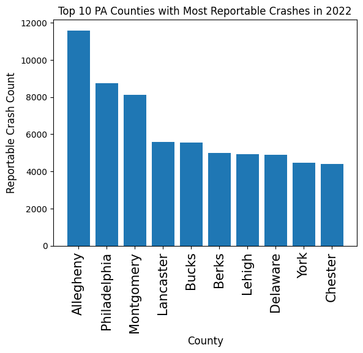

```python
fig,ax = plt.subplots(nrows=1,ncols=1)

ax.bar(top_10_county_crashes['County'], top_10_county_crashes['Reportable Crash Count'])

plt.xlabel('County', fontsize=12)
plt.ylabel('Reportable Crash Count', fontsize=12)
plt.xticks(rotation='vertical', fontsize=15)
plt.title('Top 10 PA Counties with Most Reportable Crashes in 2022')

plt.show()
```

### Question 2: What were the top 10 PA counties with the most reportable crashes per capita in 2022?

To answer this question, I needed to consider the populations of each county, which were not included in the crash dataset. I downloaded the United States Census Bureau's 2020-2023 Population Change Estimates for Pennsylvania Counties from the US Census website as a Microsoft Excel Spreadsheet and edited the sheet into a CSV file containing only the county names and 2022 population estimates [4]. I then read this CSV file into a dataframe.

```python
county_population_df = pd.read_csv('pa_2022_population_estimates_edited_census.csv')
county_population_df
```

|  | Pennsylvania County | 2022 Population |
| --- | --- | --- |
| 0 | Adams | 105959 |
| 1 | Allegheny | 1232605 |
| 2 | Armstrong | 64704 |
| 3 | Beaver | 165737 |
| 4 | Bedford | 47421 |
| ... | ... | ... |
| 62 | Wayne | 51084 |
| 63 | Westmoreland | 351998 |
| 64 | Wyoming | 26024 |
| 65 | York | 461049 |
| 66 | Philadelphia | 1566836 |

67 rows × 2 columns

I then added the population information to the county crash counts dataframe from question 1, which was made from the crash dataset. I also added a "Reportable Crash Counts per Capita" column by dividing each reportable crash count by the 2022 population.

```python
county_count_df['2022 Population'] = county_population_df['2022 Population']
county_count_df['Reportable Crash Count per Capita'] = county_count_df['Reportable Crash Count'] / county_count_df['2022 Population']

county_count_df
```

|  | County | Reportable Crash Count | 2022 Population | Reportable Crash Count per Capita |
| --- | --- | --- | --- | --- |
| 0 | Adams | 910 | 105959 | 0.008588 |
| 1 | Allegheny | 11588 | 1232605 | 0.009401 |
| 2 | Armstrong | 472 | 64704 | 0.007295 |
| 3 | Beaver | 1306 | 165737 | 0.007880 |
| 4 | Bedford | 688 | 47421 | 0.014508 |
| ... | ... | ... | ... | ... |
| 62 | Wayne | 473 | 51084 | 0.009259 |
| 63 | Westmoreland | 3064 | 351998 | 0.008705 |
| 64 | Wyoming | 263 | 26024 | 0.010106 |
| 65 | York | 4464 | 461049 | 0.009682 |
| 66 | Philadelphia | 8751 | 1566836 | 0.005585 |

67 rows × 4 columns

Using a similar method from question 1, I sliced the top 10 results of the sorted county count dataframe, stored the result in the variable "top_10_crashes_per_capita," and plotted a bar chart of the results using Matplotlib.

```python
top_10_crashes_per_capita = county_count_df.sort_values('Reportable Crash Count per Capita', ascending=False)[0:10].copy()
top_10_crashes_per_capita
```

|  | County | Reportable Crash Count | 2022 Population | Reportable Crash Count per Capita |
| --- | --- | --- | --- | --- |
| 28 | Fulton | 243 | 14554 | 0.016696 |
| 4 | Bedford | 688 | 47421 | 0.014508 |
| 44 | Monroe | 2233 | 167451 | 0.013335 |
| 38 | Lehigh | 4926 | 376274 | 0.013092 |
| 55 | Sullivan | 75 | 5845 | 0.012831 |
| 5 | Berks | 4980 | 431573 | 0.011539 |
| 15 | Clarion | 422 | 37227 | 0.011336 |
| 34 | Lackawanna | 2361 | 215750 | 0.010943 |
| 18 | Columbia | 710 | 65289 | 0.010875 |
| 56 | Susquehanna | 407 | 38139 | 0.010671 |

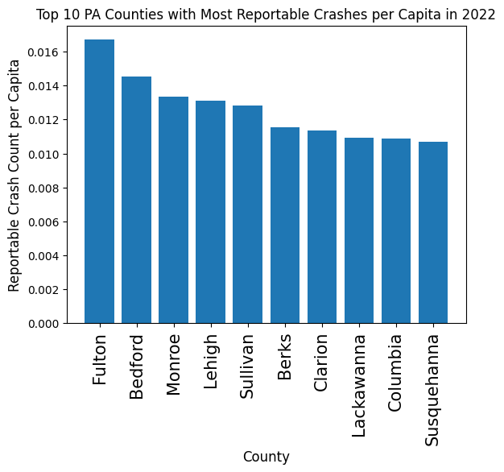

```python
fig,ax = plt.subplots(nrows=1,ncols=1)

ax.bar(top_10_crashes_per_capita['County'], top_10_crashes_per_capita['Reportable Crash Count per Capita'])

plt.xlabel('County', fontsize=12)
plt.ylabel('Reportable Crash Count per Capita', fontsize=12)
plt.xticks(rotation='vertical', fontsize=15)
plt.title('Top 10 PA Counties with Most Reportable Crashes per Capita in 2022')

plt.show()
```

Analysis:

Since population size has been taken into account, the results of the top 10 counties with the most reportable crashes change significantly. Now, none of the top three most populated counties in Pennsylvania are in the top 10. An especially interesting result is the crash per capita percentage for Fulton county, where on average nearly 1 in 60 people in the county experienced a reportable crash incident in 2022.

### Questions 3: Which months had the most crashes?

Using a similar process to the method used in question 2, I looped over the keys of the dictionary I created for months of the year to create two lists for months and the corresponding count of crashes during each month. I then put the results into a dataframe, sorted the datafrmae from largest to least counts, and visualized the results in a bar chart.

```python
month_list = []
month_count_list = []
for key in int_to_month_dict:
    month_list.append(int_to_month_dict[key])
    month_count_list.append((crash_data_less['CRASH_MONTH'] == int_to_month_dict[key]).sum())

print(month_list[0], month_count_list[0])
```

```
January 10334
```

```python
month_count_df = pd.DataFrame({"Month": month_list, "Reportable Crash Count": month_count_list})
month_count_df
```

|  | Month | Reportable Crash Count |
| --- | --- | --- |
| 0 | January | 10334 |
| 1 | February | 8705 |
| 2 | March | 9434 |
| 3 | April | 8456 |
| 4 | May | 9802 |
| 5 | June | 9107 |
| 6 | July | 8625 |
| 7 | August | 9141 |
| 8 | September | 9294 |
| 9 | October | 10926 |
| 10 | November | 10777 |
| 11 | December | 11435 |

```python
top_months = month_count_df.sort_values('Reportable Crash Count', ascending=False).copy()
top_months
```

|  | Month | Reportable Crash Count |
| --- | --- | --- |
| 11 | December | 11435 |
| 9 | October | 10926 |
| 10 | November | 10777 |
| 0 | January | 10334 |
| 4 | May | 9802 |
| 2 | March | 9434 |
| 8 | September | 9294 |
| 7 | August | 9141 |
| 5 | June | 9107 |
| 1 | February | 8705 |
| 6 | July | 8625 |
| 3 | April | 8456 |

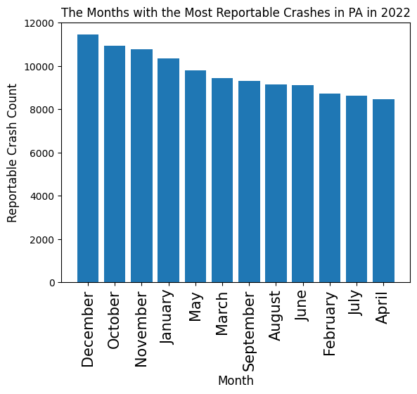

```python
fig,ax = plt.subplots(nrows=1,ncols=1)

ax.bar(top_months['Month'], top_months['Reportable Crash Count'])

plt.xlabel('Month', fontsize=12)
plt.ylabel('Reportable Crash Count', fontsize=12)
plt.xticks(rotation='vertical', fontsize=15)
plt.title('The Months with the Most Reportable Crashes in PA in 2022')

plt.show()
```

Analysis:

An interesting observation from this chart is that most of the accidents during the year in 2022 happened during the fall and winter months. This would align with the idea that, at least in Pennsylvania, driving can become more difficult as inclement weather conditions arrive in the later months of the year.

### Question 4: Which days had the most crashes?

```python
day_list = []
day_count_list = []
for key in int_to_day_dict:
    day_list.append(int_to_day_dict[key])
    day_count_list.append((crash_data_less['DAY_OF_WEEK'] == int_to_day_dict[key]).sum())

print(day_list[-1], day_count_list[-1])
```

```
Unknown 0
```

One element to note is that in the original crash dataset, an "unknown" value for day of the week was included to consider crashes with an unknown day. However, as shown above, this value never appears in any of the dataset's rows. Because of this, I removed the "unknown" day and its count from the two lists, and proceeded with creating the day count dataframe.

```python
day_list.pop(-1)
day_count_list.pop(-1)

day_count_df = pd.DataFrame({"Day": day_list, "Reportable Crash Count": day_count_list})

top_days = day_count_df.sort_values('Reportable Crash Count', ascending=False).copy()
top_days
```

|  | Day | Reportable Crash Count |
| --- | --- | --- |
| 5 | Friday | 19158 |
| 4 | Thursday | 17478 |
| 6 | Saturday | 17259 |
| 3 | Wednesday | 16211 |
| 2 | Tuesday | 16066 |
| 1 | Monday | 15452 |
| 0 | Sunday | 14412 |

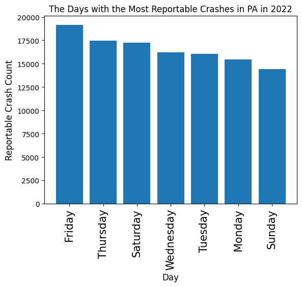

```python
fig,ax = plt.subplots(nrows=1,ncols=1)

ax.bar(top_days['Day'], top_days['Reportable Crash Count'])

plt.xlabel('Day', fontsize=12)
plt.ylabel('Reportable Crash Count', fontsize=12)
plt.xticks(rotation='vertical', fontsize=15)
plt.title('The Days with the Most Reportable Crashes in PA in 2022')

plt.show()
```

Analysis:

Interestingly, driving on a Friday resulted in the most PA reportable crashes in 2022, relative to the other days of the week, while Saturday had the third most. This could suggest that driving on a weekend may have an influence on accident rates in PA counties. However, in contrast to this, Sunday had the least amount of crashes.

### Question 5: What were the top 10 hours of the day that had the most crashes?

Using the same process as the other questions, I used a for loop to populate two lists for the counts of reportable crashes for each hour of the day. However, the variable 'HOUR_OF_DAY' in the crash dataset was only reported as float values between 0 and 23. To make the results more understandable, I created a dictionary to convert the float values to string representations of each hour of the day, and used this dictionary to populate the list of hour labels. I then sorted a dataframe of the two lists and visualized the results.

```python
float_to_hour = {0.0: '12:00 AM', 1.0: '1:00 AM', 2.0: '2:00 AM', 3.0: '3:00 AM', 4.0: '4:00 AM', 5.0: '5:00 AM', 6.0: '6:00 AM', 7.0: '7:00 AM', 8.0: '8:00 AM', 9.0: '9:00 AM', 10.0: '10:00 AM', 11.0: '11:00 AM',
 12.0: '12:00 PM', 13.0: '1:00 PM', 14.0: '2:00 PM', 15.0: '3:00 PM', 16.0: '4:00 PM', 17.0: '5:00 PM', 18.0: '6:00 PM', 19.0: '7:00 PM', 20.0: '8:00 PM', 21.0: '9:00 PM', 22.0: '10:00 PM', 23.0: '11:00 PM'}

hour_list = []
hour_count_list = []
for hour in float_to_hour:
    hour_list.append(float_to_hour[hour])
    hour_count_list.append((crash_data_less['HOUR_OF_DAY'] == hour).sum())

hour_count_df = pd.DataFrame({"Hour of Day": hour_list, "Reportable Crash Count": hour_count_list})

top_hours = hour_count_df.sort_values('Reportable Crash Count', ascending=False)[0:10].copy()
top_hours
```

|  | Hour of Day | Reportable Crash Count |
| --- | --- | --- |
| 15 | 3:00 PM | 8593 |
| 17 | 5:00 PM | 8334 |
| 16 | 4:00 PM | 8328 |
| 14 | 2:00 PM | 7052 |
| 18 | 6:00 PM | 6502 |
| 13 | 1:00 PM | 5967 |
| 12 | 12:00 PM | 5904 |
| 7 | 7:00 AM | 5679 |
| 8 | 8:00 AM | 5361 |
| 11 | 11:00 AM | 5319 |

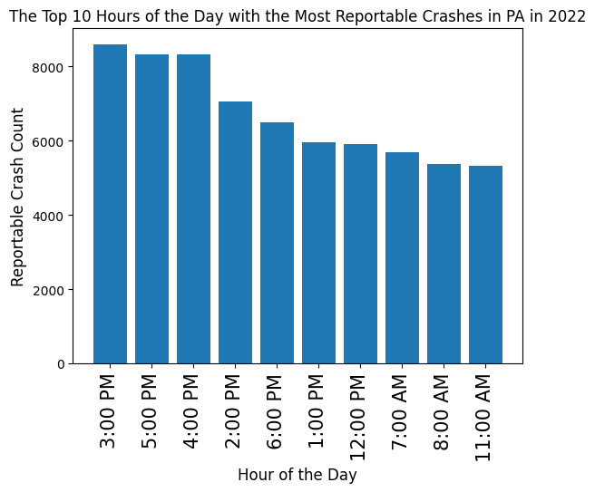

```python
fig,ax = plt.subplots(nrows=1,ncols=1)

ax.bar(top_hours['Hour of Day'], top_hours['Reportable Crash Count'])

plt.xlabel('Hour of the Day', fontsize=12)
plt.ylabel('Reportable Crash Count', fontsize=12)
plt.xticks(rotation='vertical', fontsize=15)
plt.title('The Top 10 Hours of the Day with the Most Reportable Crashes in PA in 2022')

plt.show()
```

Analysis:

A notable result from this graph is that the top four hours of the day for reportable crashes in PA in 2022 was a four hour period from 2:00PM-5:00PM. This could suggest that more accidents happen during the time of the day commonly refered to as "rush hour," the several-hour span after typical working hours where commuting traffic can be high.

### Question 6: Of crashes for drivers aged 16-20, 50-64, 65-74, and 75+, which age group had the most drivers involved?

```python
age_group_list = ['16-20', '50-64', '65-74', '75+']
age_group_counts = []

age_group_counts.append(crash_data_less['DRIVER_COUNT_16YR'].sum() + crash_data_less['DRIVER_COUNT_17YR'].sum() + crash_data_less['DRIVER_COUNT_18YR'].sum() + crash_data_less['DRIVER_COUNT_19YR'].sum()
+ crash_data_less['DRIVER_COUNT_19YR'].sum() + crash_data_less['DRIVER_COUNT_20YR'].sum())

age_group_counts.append((crash_data_less['DRIVER_COUNT_50_64YR'].sum()))

age_group_counts.append((crash_data_less['DRIVER_COUNT_65_74YR'].sum()))

age_group_counts.append((crash_data_less['DRIVER_COUNT_75PLUS'].sum()))

age_df = pd.DataFrame({'Age Group': age_group_list, 'Reportable Crash Count': age_group_counts})
age_df
```

|  | Age Group | Reportable Crash Count |
| --- | --- | --- |
| 0 | 16-20 | 26512 |
| 1 | 50-64 | 34844 |
| 2 | 65-74 | 13976 |
| 3 | 75+ | 8321 |

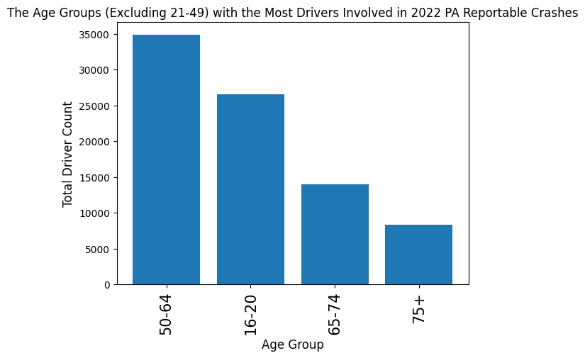

```python
age_df = age_df.sort_values('Reportable Crash Count', ascending=False)[0:10].copy()

fig,ax = plt.subplots(nrows=1,ncols=1)

ax.bar(age_df['Age Group'], age_df['Reportable Crash Count'])

plt.xlabel('Age Group', fontsize=12)
plt.ylabel('Total Driver Count', fontsize=12)
plt.xticks(rotation='vertical', fontsize=15)
plt.title('The Age Groups (Excluding 21-49) with the Most Drivers Involved in 2022 PA Reportable Crashes')

plt.show()
```

Analysis:

### Question 7: Of crashes for drivers aged 16, 17, 18, and 20 which age group had the most drivers involved?

```python
age_group_list = ['16', '17', '18', '19', '20']
age_group_counts = []

age_group_counts.append(crash_data_less['DRIVER_COUNT_16YR'].sum())

age_group_counts.append(crash_data_less['DRIVER_COUNT_17YR'].sum())

age_group_counts.append(crash_data_less['DRIVER_COUNT_18YR'].sum())

age_group_counts.append(crash_data_less['DRIVER_COUNT_19YR'].sum())

age_group_counts.append(crash_data_less['DRIVER_COUNT_19YR'].sum())

young_age_df = pd.DataFrame({'Age Group': age_group_list, 'Reportable Crash Count': age_group_counts})
young_age_df
```

|  | Age Group | Reportable Crash Count |
| --- | --- | --- |
| 0 | 16 | 1950 |
| 1 | 17 | 4516 |
| 2 | 18 | 5179 |
| 3 | 19 | 4962 |
| 4 | 20 | 4962 |

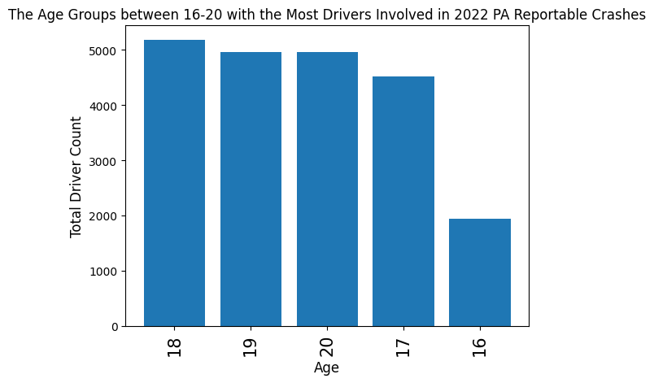

```python
young_age_df = young_age_df.sort_values('Reportable Crash Count', ascending=False)[0:10].copy()

fig,ax = plt.subplots(nrows=1,ncols=1)

ax.bar(young_age_df['Age Group'], young_age_df['Reportable Crash Count'])

plt.xlabel('Age', fontsize=12)
plt.ylabel('Total Driver Count', fontsize=12)
plt.xticks(rotation='vertical', fontsize=15)
plt.title('The Age Groups between 16-20 with the Most Drivers Involved in 2022 PA Reportable Crashes')

plt.show()
```

## Discussion of Findings and Conclusion

This project has evaluated various trends present in the dataset for reportable crashes in Pennsylvania during 2022. While each question addressed in the project evaluated a different aspect of the data related to crashes, the observations paint a larger picture of different and potentially underlooked factors that could contribute to crashes. This particularly applies to the questions addressing the times of day and months of the year with the most crashes, as the "rush-hour" period and late fall/early winter months both held the highest counts of crashes. These findings could inform state and county lawmakers to reconsider how they distribute first-responder-services during the hours of the day and months of the year to better accomodate for periods of high crash frequency.

## Sources

1. Center for Rural Pennsylvania Infographic on Percentage of Population Age 16 or Older with a Driver's License by County (using data from the PennDOT Bureau of Driver Licensing) - https://www.rural.pa.gov/datagram/602/Percentage-of-Population-Age-16-or-Older-with-a-Drivers-License-by-County
2. Pennsylvania Department of Transportation (PennDOT) Crash Information Tool public crash dataset download map - https://pennshare.maps.arcgis.com/apps/webappviewer/index.html?id=8fdbf046e36e41649bbfd9d7dd7c7e7e
3. PennDOT Open Data Portal Crash Data Dictionary and Field Constraints Tables - https://gis.penndot.gov/gishub/crashZip/Crash%20Data%20Dictionary%2005.2023.pdf
4. United States Census Bureau County Population Totals and Components of Change: 2020-2023 Website - https://www.census.gov/data/tables/time-series/demo/popest/2020s-counties-total.html#v2022
5. PennDOT "Pennsylvania Senior Citizens Non-Commercial Driver's Licennse and Vechicle Registration Services" fact sheet - https://www.dot.state.pa.us/public/dvspubsforms/bmv/bmv%20fact%20sheets/fs-pasen.pdf